# Data Exploration

October 2024

## Differential Gene Expression Analysis Workflow

[figure not shown]

## Overview

This session covers:

1. **Why explore your data first?**
2. **Properties of RNA-seq count data**
3. **Normalisation: why TPM/FPKM aren’t enough**
4. **Data transformations** (rlog / VST)
5. **Principal Component Analysis (PCA)**
6. **Hierarchical clustering**
7. **Interpreting (or not) clusters**

## EDA: Quality Control *and* Biological Insight

**Before trusting your results, make sure your data makes sense.**

Exploratory Data Analysis (EDA) serves two complementary purposes:

**Quality control**

- Are the samples what we think they are?
- Are there outliers, swapped labels, or batch effects?
- Does the overall signal look as expected?

**Early biological insight**

- Which experimental factors drive the largest variation?
- Do replicates behave consistently?
- Are there unexpected groupings that suggest confounders?

## What Can Go Wrong?

Exploratory analysis - boxplots, PCA, clustering - help catch issues quickly.

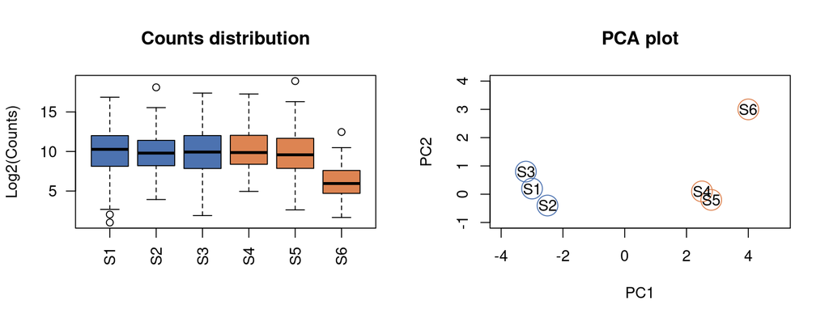

## Properties of Count Data

**RNA-seq produces count data:** After alignment/quantification, each transcript/gene gets a **count** - the number of reads assigned to it.

Key properties of count data:

- Counts are **non-negative integers**
- Distribution is **right-skewed** - a few genes with very high counts
- Variance is **not constant** - it scales with the mean

## Distribution Skew

A simple log transformation helps to compress the range and make distribution pattern more visible. We often add a pseudocount of 1 to avoid the issue of log(0) = -Inf.

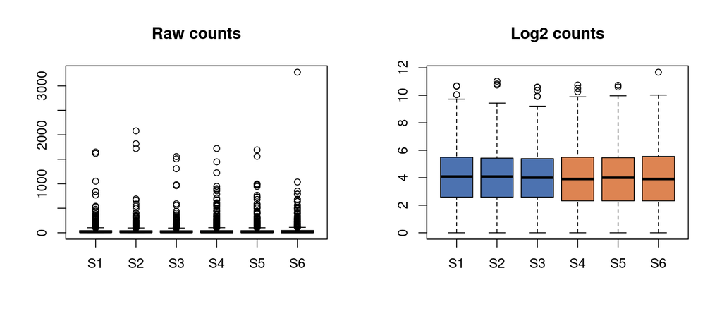

## The Mean-Variance Problem

In RNA-seq data, **genes with higher average expression also tend to show higher variability** between samples.

Clustering and PCA are **distance-based** - highly variable genes will dominate if not taken into account.

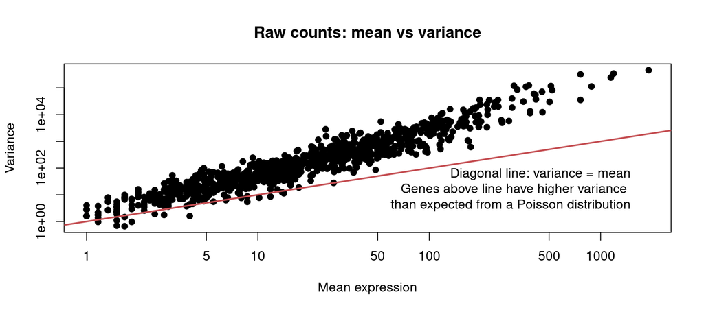

## Stabilising the Variance: rlog and VST

DESeq2 provides two transformations that simultaneously:

- **log-transform** the data (compresses the range)
- **Normalise for library size** (using size factors)
- **Stabilise variance of lowly expressed genes**

|  | **Regularised log** | **Variance Stabilising Transformation** |
| --- | --- | --- |
| Function | `rlog()` | `vst()` |
| Speed | Slower | Faster |
| Best for | Small datasets, unequal library sizes | Large datasets (>30-50 samples) |

## Before and After Transformation

After transformation, genes across the expression spectrum contribute more **“equally”** to downstream analyses.

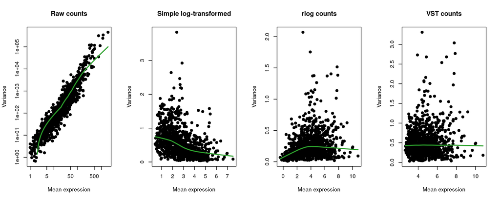

## Why Not Just Use TPM or FPKM?

TPM and FPKM correct for **gene length** and **sequencing depth** - but have a critical flaw for *comparing samples*.

Normalising to the *total* count means a massively up-regulated gene makes all others *appear* artificially lower.

See:

- Evans C, Hardin J, Stoebel DM (2018). Selecting between-sample RNA-Seq normalization methods from the perspective of their assumptions. *Briefings in Bioinformatics*. https://doi.org/10.1093/bib/bbx008
- Zhao S, Ye Z, Stanton R (2020). Misuse of RPKM or TPM normalization when comparing across samples and sequencing protocols. *RNA*. https://doi.org/10.1261/rna.074922.120
- Zhao Y, Li MC, Konaté M, Chen L, Das B, Karlovich C, Williams PM, Evrard YA, Doroshow JH, McShane LM (2021). TPM, FPKM, or Normalized Counts? A Comparative Study of Quantification Measures for the Analysis of RNA-seq Data from the NCI Patient-Derived Models Repository. *Journal of Translational Medicine*. https://doi.org/10.1186/s12967-021-02936-w

*Fig. 1 in Evans et al. particularly illustrates the problem nicely.*

## DESeq2’s Solution: Size Factors

DESeq2 calculates **size factors** using the *median-of-ratios* method - robust to highly expressed or DE genes.

**How it works:**

1. For each gene, compute the **geometric mean** count across all samples *(a “pseudo-reference” sample)*
2. For each sample, divide each gene’s count by its reference value *(a ratio per gene per sample)*
3. Take the **median** of all those ratios for each sample *(the median resists the few genes that are truly DE)*
4. That median is the **size factor** - divide all counts by it

The key assumption: most genes are **not** differentially expressed, so the median ratio captures genuine library size differences.

## Size Factor Example

| Gene | Sample A | Sample B | Geometric mean | Ratio A | Ratio B |
| --- | --- | --- | --- | --- | --- |
| G1 | 20 | 40 | 28.3 | 0.71 | 1.41 |
| G2 | 40 | 80 | 56.6 | 0.71 | 1.41 |
| G3 | 10 | 20 | 14.1 | 0.71 | 1.41 |
| G4 | 230 | 160 | 191.8 | 1.20 | 0.83 |

- Size factor A = median(Ratio A) = 0.71
- Size factor B = median(Ratio B) = 1.41

Notice how the highly expressed gene G4 has a different ratio, but it does not affect the size factor.

After dividing each sample’s counts by its size factor, samples are comparable - **without assuming total counts should be equal**.

## When to Use Transformed vs Raw Counts

VST/rlog can be used for:

- **PCA**
- **Hierarchical clustering**
- **Heatmaps**
- **Other machine learning or multivariate methods**

**Differential expression** uses raw counts.

For **cross-sample comparisons** avoid TPM/FPKM.

## Principal component analysis (PCA)

PCA is an **unsupervised** dimensionality reduction method - it finds the directions of greatest variation in high-dimensional data.

PCA considers **all genes simultaneously** to capture major patterns into a small number of axes.

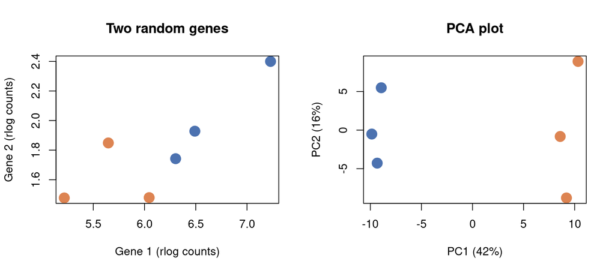

## What PCA Can Reveal

**A well-behaved experiment:**

- Replicates cluster tightly together
- Groups are well separated along PC1 or PC2
- PC axes correspond to the expected biology (e.g. treatment, time point)

**Warning signs to look for:**

- A replicate far from its group - possible outlier or labelling error
- Samples group by batch / processing date, not biology - **batch effect**

## Alternative methods

Hierarchical clustering and sample-sample correlation heatmaps are also commonly used to explore sample relationships.

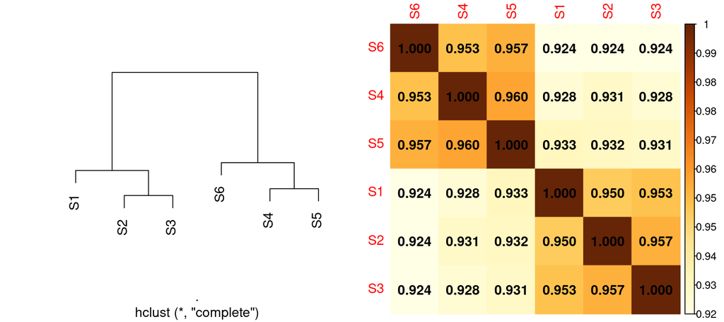

## What if samples don’t cluster?

It is not uncommon for samples not to show clear clustering by treatment group in PCA or hierarchical clustering.

This can be due to:

- The treatment has a subtle effect, affecting only a small number of genes.
- There is high biological variability (e.g. very common in non-controlled experiments, such as human samples).
- There are technical issues (e.g. batch effects, sample swaps, outliers) that are obscuring the biological signal.
- There is no real biological signal in the data (e.g. the treatment has no effect).